# Periodogram

Dáta v súbore Napatie.txt predstavujú signál napätia v sieti.

#### Načítanie a zobrazenie dát

```r
Napatie <- read.csv2("Napatie.txt", sep="")
str(Napatie)
```

```
## 'data.frame':    500 obs. of  1 variable:
##  $ Signal: num  4.823 -4.448 3.915 -1.411 -0.883 ...
```

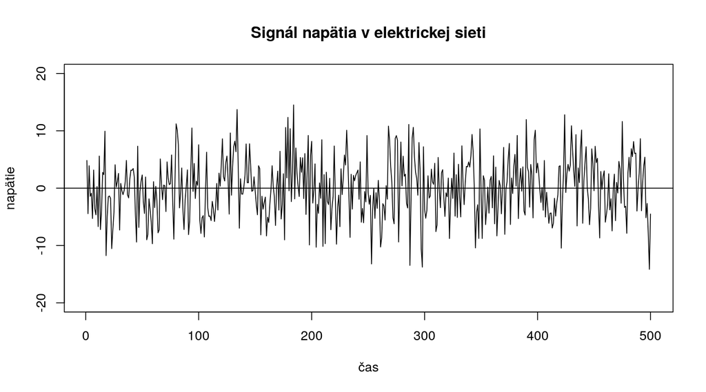

```r
Signal<-Napatie$Signal
t<-1:500
plot(t,Signal,type="l",ylim=c(-20,20), xlab="čas",ylab="napätie", main = "Signál napätia v elektrickej sieti")
abline(0,0)
```

#### Pozorovanie

- variabilita ustálená
- sezónna zložka
- rad je zrejme ustálený
- vyzerá to na nejakú periodickú zložku

#### Analýza reziduí

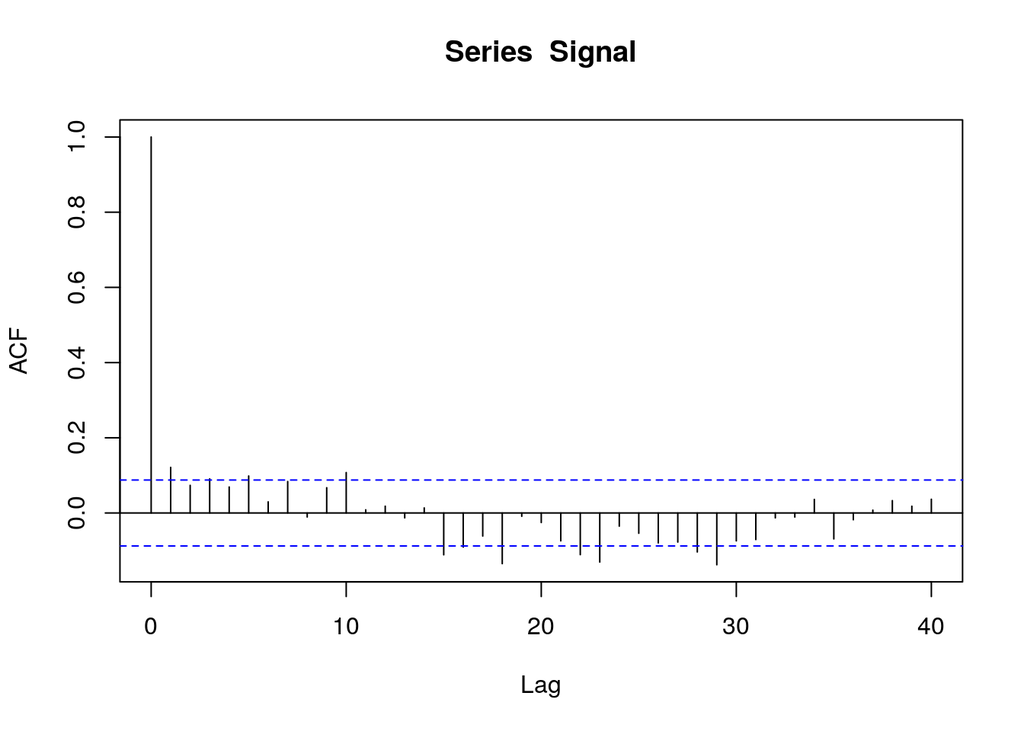

```r
acf(Signal, 40)
```

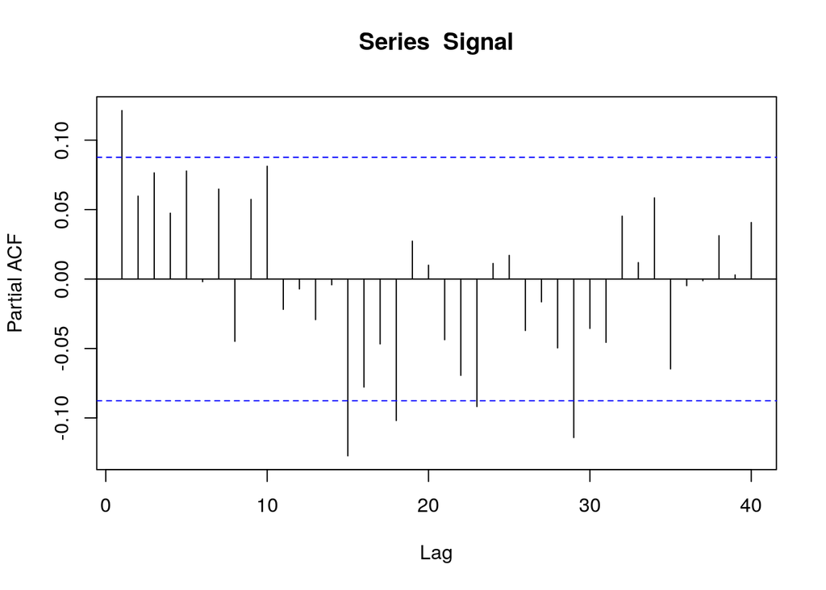

```r
pacf(Signal, 40)
```

```r
Box.test(Signal)
```

```
##
##  Box-Pierce test
##
## data:  Signal
## X-squared = 7.3544, df = 1, p-value = 0.00669
```

```r
Box.test(Signal, type = 'Ljung')
```

```
##
##  Box-Ljung test
##
## data:  Signal
## X-squared = 7.3986, df = 1, p-value = 0.006527
```

```r
#resSignal <- residuals(Signal)
#plot(resSignal, main = 'Reziduá', xlab = 'čas')
```

**ACF a PACF:** Nenaznačujú žiaden model, dáta sú však stále nejako závislé.

**Box testy:** Zamietajú hypotézu o nezávislosti dát. Dáta sú závislé.

Analýza v časovej oblasti nám teda neodhalila nič zaujímavé a tak skúsime analýzu vo *frekvenčnej oblasti*.

#### Periodogram v R

Periodogram:
$$I(\lambda) = \frac{1}{n}|\sum_{t=1}^{\mu}X_t e^{-i\lambda t}|^2$$
Táto funkcia je odhadom násobku spektrálnej hustoty $2\pi f(\lambda)$. Funguje to však len vo frekvenciách $\lambda_k = \frac{2\pi k}{n}$; $\lambda \in <0; \pi>$.

V našom prípade máme 500 hodnôt, takže prejdeme cez všetky hodnoty:
$$\lambda_1 = 2\pi/500, \lambda_2 = 2\pi\cdot2/500, ...$$

Na výpočet a znázornenie periodogramu je v R príkaz spec.pgram

```r
signalPeriod <- spec.pgram(Signal, log="no")
```

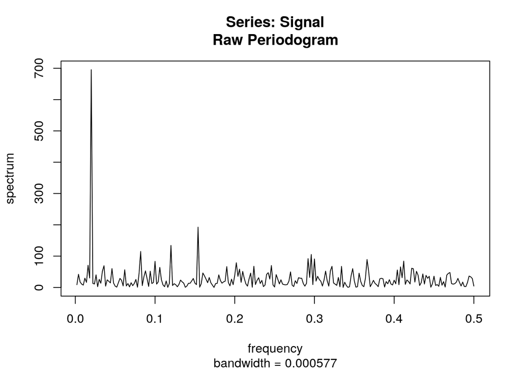

```r
signalPeriod
```

```
## $freq
##   [1] 0.002 0.004 0.006 0.008 0.010 0.012 0.014 0.016 0.018 0.020 0.022
##  [12] 0.024 0.026 0.028 0.030 0.032 0.034 0.036 0.038 0.040 0.042 0.044
##  [23] 0.046 0.048 0.050 0.052 0.054 0.056 0.058 0.060 0.062 0.064 0.066
##  [34] 0.068 0.070 0.072 0.074 0.076 0.078 0.080 0.082 0.084 0.086 0.088
##  [45] 0.090 0.092 0.094 0.096 0.098 0.100 0.102 0.104 0.106 0.108 0.110
##  [56] 0.112 0.114 0.116 0.118 0.120 0.122 0.124 0.126 0.128 0.130 0.132
##  [67] 0.134 0.136 0.138 0.140 0.142 0.144 0.146 0.148 0.150 0.152 0.154
##  [78] 0.156 0.158 0.160 0.162 0.164 0.166 0.168 0.170 0.172 0.174 0.176
##  [89] 0.178 0.180 0.182 0.184 0.186 0.188 0.190 0.192 0.194 0.196 0.198
## [100] 0.200 0.202 0.204 0.206 0.208 0.210 0.212 0.214 0.216 0.218 0.220
## [111] 0.222 0.224 0.226 0.228 0.230 0.232 0.234 0.236 0.238 0.240 0.242
## [122] 0.244 0.246 0.248 0.250 0.252 0.254 0.256 0.258 0.260 0.262 0.264
## [133] 0.266 0.268 0.270 0.272 0.274 0.276 0.278 0.280 0.282 0.284 0.286
## [144] 0.288 0.290 0.292 0.294 0.296 0.298 0.300 0.302 0.304 0.306 0.308
## [155] 0.310 0.312 0.314 0.316 0.318 0.320 0.322 0.324 0.326 0.328 0.330
## [166] 0.332 0.334 0.336 0.338 0.340 0.342 0.344 0.346 0.348 0.350 0.352
## [177] 0.354 0.356 0.358 0.360 0.362 0.364 0.366 0.368 0.370 0.372 0.374
## [188] 0.376 0.378 0.380 0.382 0.384 0.386 0.388 0.390 0.392 0.394 0.396
## [199] 0.398 0.400 0.402 0.404 0.406 0.408 0.410 0.412 0.414 0.416 0.418
## [210] 0.420 0.422 0.424 0.426 0.428 0.430 0.432 0.434 0.436 0.438 0.440
## [221] 0.442 0.444 0.446 0.448 0.450 0.452 0.454 0.456 0.458 0.460 0.462
## [232] 0.464 0.466 0.468 0.470 0.472 0.474 0.476 0.478 0.480 0.482 0.484
## [243] 0.486 0.488 0.490 0.492 0.494 0.496 0.498 0.500
##
## $spec
##   [1]   8.8113335  41.9024571  17.4734543  10.5954975   7.4652915
##   [6]  29.6712269  16.2888248  70.7193629  30.0990673 695.4663399
##  [11]  12.7957127  11.0198882  40.1491649   2.4909064  25.7822223
##  [16]  13.5270201  52.0242755  69.3729133   4.1664769  24.2578279
##  [21]  19.5632440  14.5922713  60.1574973  13.9608436   4.1318032
##  [26]   1.0475118  14.8628494  28.9273273  22.8496172   4.8441815
##  [31]  56.3671594   4.7409673  12.4881347   1.7673623  15.0583435
##  [36]   5.6470269  12.6397128  25.5340763   0.7456775  45.4864591
##  [41] 114.9570237   5.8199451  33.4831330  52.8349751  28.4042071
##  [46]   3.3141576  51.8658402  12.5114503  15.8529872  83.3841956
##  [51]  10.6488370  17.6646916  63.9837250  24.7074257   8.1356001
##  [56]   2.4300087  20.6410132   0.3457352  12.8217961 134.1169218
##  [61]   6.0970447  11.8989177   8.6732384   2.1843098   9.6929576
##  [66]  23.4555041  17.9467213  13.7316382   0.4957603   4.5489565
```

[output cut: 66 more lines]

```
##
## $taper
## [1] 0.1
##
## $pad
## [1] 0
##
## $detrend
## [1] TRUE
##
## $demean
## [1] FALSE
##
## attr(,"class")
## [1] "spec"
```

Výstup je grafický ale výpisom môžeme ľahko zistiť významné frekvencie. Vidíme, že signalPeriod$freq obsahuje iba $1/k$, $2\pi$ si musíme domyslieť. Najväčšie maximum v periodograme zodpovedá desiatej hodnote: $2\pi\cdot10/500 = 2\pi/50 = 2\pi\cdot0.02$. Keďže máme len jednu významnú frekvencie, naznačuje nám to použitie modelu
$$\beta_1\mathrm{cos}\left(\dfrac{2\pi}{50}t\right)+\beta_2\mathrm{sin}\left(\dfrac{2\pi}{50}t\right)$$

#### Nájdenie modelu periodickej zložky v tvare $\beta_1\mathrm{cos}\left(\dfrac{2\pi }{50}t\right)+\beta_2\mathrm{sin}\left(\dfrac{2\pi}{50}t\right)$

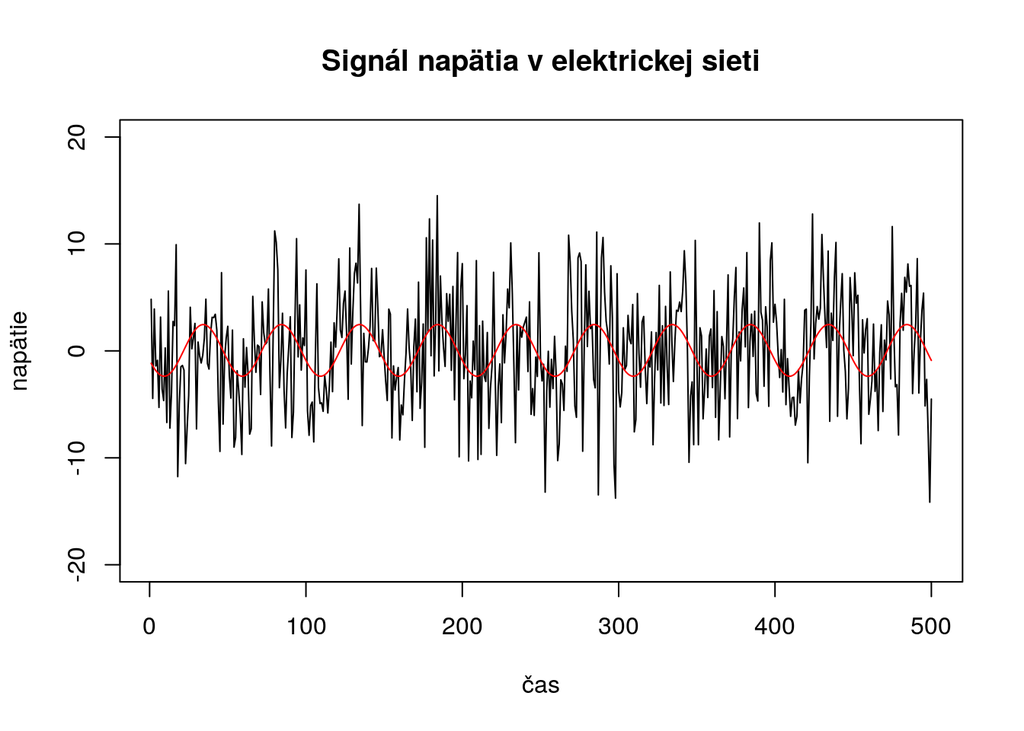

```r
t <- 1:length(Signal)
sint = sin(2*pi*t/50)
cost = cos(2*pi*t/50)

modelSignal = lm(Signal~sint+cost)
plot(t,Signal,type="l",ylim=c(-20,20), xlab="čas",ylab="napätie", main = "Signál napätia v elektrickej sieti")
lines(t, predict(modelSignal), col = 'red')
```

Je toto dostatočné? Vieme, že reziduá už sú už nezávislé?

#### Reziduá

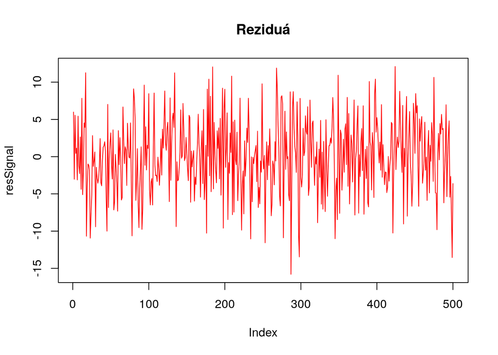

```r
resSignal <- residuals(modelSignal)
plot(resSignal, main = 'Reziduá', col = 'red', type = 'l')
```

#### Analýza reziduí

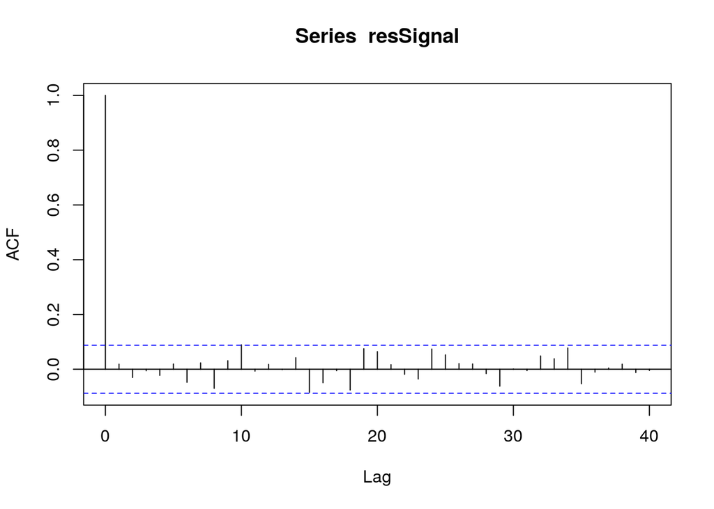

```r
acf(resSignal, 40)
```

```r
Box.test(resSignal)
```

```
##
##  Box-Pierce test
##
## data:  resSignal
## X-squared = 0.17136, df = 1, p-value = 0.6789
```

```r
Box.test(resSignal, type = 'Ljung')
```

```
##
##  Box-Ljung test
##
## data:  resSignal
## X-squared = 0.17239, df = 1, p-value = 0.678
```

Ešte by nás mohlo zaujímať z akého rozdelenia sú reziduá. Ak by boli z normálneho rozdelenia, tak vieme robiť nejaké intervaly spoľahlivosti. Prvý náznak, že sú z normálneho rozdelenia dostaneme z pohľadu na histogram. Taktiež môžeme využiť **Shapiro-Wilk test normality**: Nulová hypotéza je, že máme normálne rozdelenie.

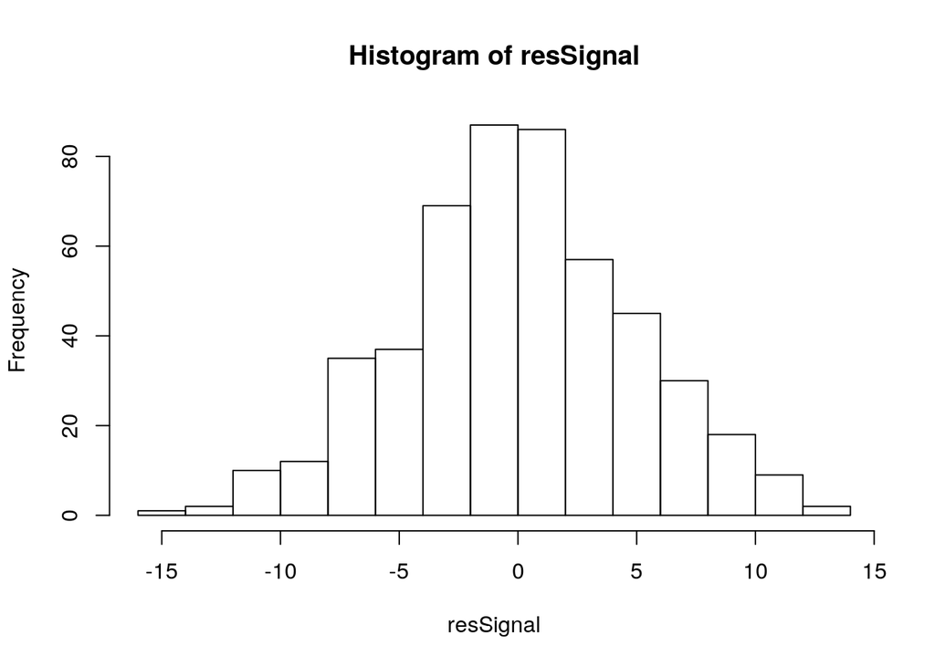

```r
hist(resSignal)
```

```r
shapiro.test(resSignal)
```

```
##
##  Shapiro-Wilk normality test
##
## data:  resSignal
## W = 0.99691, p-value = 0.4618
```

Z histogramu vidíme, že dáta by mohli byť z normálneho rozdelenia, Shapiro-Wilk test nám tiež nedáva dôvod zamietať hypotézu o normalite, a tak môžeme zapísať model.

#### Zápis kompletného modelu

```r
summary(modelSignal)
```

```
##
## Call:
## lm(formula = Signal ~ sint + cost)
##
## Residuals:
##     Min      1Q  Median      3Q     Max
## -15.796  -3.292  -0.063   3.477  12.101
##
## Coefficients:
##             Estimate Std. Error t value Pr(>|t|)
## (Intercept)  0.04589    0.22320   0.206  0.83717
## sint        -2.22824    0.31565  -7.059 5.67e-12 ***
## cost        -0.93715    0.31565  -2.969  0.00313 **
## ---
## Signif. codes:  0 '***' 0.001 '**' 0.01 '*' 0.05 '.' 0.1 ' ' 1
##
## Residual standard error: 4.991 on 497 degrees of freedom
## Multiple R-squared:  0.1055, Adjusted R-squared:  0.1019
## F-statistic: 29.32 on 2 and 497 DF,  p-value: 9.166e-13
```

Intercept nie je dôležitý, takže môžeme brať model bez absolútneho člena.

$$X(t)=-2.22824 \cdot \mathrm{sin}\left(\dfrac{2\pi}{50}t\right) - 0.93715 \cdot \mathrm{cos}\left(\dfrac{2\pi }{50}t\right) + Z_t,$$
kde $Z_t \sim WN(0,\sigma^2)$ a $\hat{\sigma}=4.991$

Testy majú zmysel len ak naše reziduá sú normálne rozdelené, čo sme aj overili. $Z_t \sim N(0,\sigma^2)$

#### Overenie odhadu smerodajnej odchýlky reziduí

$$SSE = \sqrt{\frac{\sum_i(y_i-\hat{y_i})^2}{n-k}}$$
kde $y_i$ sú skutočné dáta, $\hat{y_i}$ je fit, $y_i-\hat{y_i}$ sú reziduá, $n$ je počet dát a $k$ je počet parametrov.

```r
SSE <- sqrt(sum(resSignal^2)/(length(Signal)-3))
SSE
```

```
## [1] 4.990912
```